# Risk Factor Analysis

## Outcome Variable

**Outcome Variable:** whz

## Predictor Variables

**Intervention Variable:** parity

**Adjustment Set:**

unadjusted

## Stratifying Variables

The analysis was stratified on these variable(s):

- agecat
- studyid
- country

## Data Summary

| agecat | studyid | country | parity | n_cell | n |
| --- | --- | --- | --- | --- | --- |
| Birth | ki1000304b-SAS-CompFeed | INDIA | 1 | 41 | 166 |
| Birth | ki1000304b-SAS-CompFeed | INDIA | 2 | 44 | 166 |
| Birth | ki1000304b-SAS-CompFeed | INDIA | 3+ | 81 | 166 |
| Birth | ki1101329-Keneba | GAMBIA | 1 | 142 | 1292 |
| Birth | ki1101329-Keneba | GAMBIA | 2 | 133 | 1292 |
| Birth | ki1101329-Keneba | GAMBIA | 3+ | 1017 | 1292 |
| Birth | ki1126311-ZVITAMBO | ZIMBABWE | 1 | 5561 | 12915 |
| Birth | ki1126311-ZVITAMBO | ZIMBABWE | 2 | 3882 | 12915 |
| Birth | ki1126311-ZVITAMBO | ZIMBABWE | 3+ | 3472 | 12915 |
| Birth | ki1135781-COHORTS | GUATEMALA | 1 | 94 | 756 |
| Birth | ki1135781-COHORTS | GUATEMALA | 2 | 118 | 756 |
| Birth | ki1135781-COHORTS | GUATEMALA | 3+ | 544 | 756 |
| Birth | ki1135781-COHORTS | INDIA | 1 | 641 | 3855 |
| Birth | ki1135781-COHORTS | INDIA | 2 | 982 | 3855 |
| Birth | ki1135781-COHORTS | INDIA | 3+ | 2232 | 3855 |
| Birth | ki1135781-COHORTS | PHILIPPINES | 1 | 640 | 2899 |
| Birth | ki1135781-COHORTS | PHILIPPINES | 2 | 657 | 2899 |
| Birth | ki1135781-COHORTS | PHILIPPINES | 3+ | 1602 | 2899 |
| Birth | kiGH5241-JiVitA-3 | BANGLADESH | 1 | 4604 | 15692 |
| Birth | kiGH5241-JiVitA-3 | BANGLADESH | 2 | 5539 | 15692 |
| Birth | kiGH5241-JiVitA-3 | BANGLADESH | 3+ | 5549 | 15692 |
| 6 months | ki1000304b-SAS-CompFeed | INDIA | 1 | 392 | 1334 |
| 6 months | ki1000304b-SAS-CompFeed | INDIA | 2 | 302 | 1334 |
| 6 months | ki1000304b-SAS-CompFeed | INDIA | 3+ | 640 | 1334 |
| 6 months | ki1000304b-SAS-FoodSuppl | INDIA | 1 | 72 | 373 |
| 6 months | ki1000304b-SAS-FoodSuppl | INDIA | 2 | 84 | 373 |
| 6 months | ki1000304b-SAS-FoodSuppl | INDIA | 3+ | 217 | 373 |
| 6 months | ki1017093b-PROVIDE | BANGLADESH | 1 | 211 | 582 |
| 6 months | ki1017093b-PROVIDE | BANGLADESH | 2 | 212 | 582 |
| 6 months | ki1017093b-PROVIDE | BANGLADESH | 3+ | 159 | 582 |

[output cut: 51 more lines]

The following strata were considered:

- agecat: 24 months, studyid: ki1017093b-PROVIDE, country: BANGLADESH
- agecat: 24 months, studyid: ki1066203-TanzaniaChild2, country: TANZANIA, UNITED REPUBLIC OF
- agecat: 24 months, studyid: ki1101329-Keneba, country: GAMBIA
- agecat: 24 months, studyid: ki1113344-GMS-Nepal, country: NEPAL
- agecat: 24 months, studyid: ki1126311-ZVITAMBO, country: ZIMBABWE
- agecat: 24 months, studyid: ki1135781-COHORTS, country: GUATEMALA
- agecat: 24 months, studyid: ki1135781-COHORTS, country: INDIA
- agecat: 24 months, studyid: ki1135781-COHORTS, country: PHILIPPINES
- agecat: 24 months, studyid: kiGH5241-JiVitA-3, country: BANGLADESH
- agecat: 6 months, studyid: ki1000304b-SAS-CompFeed, country: INDIA
- agecat: 6 months, studyid: ki1000304b-SAS-FoodSuppl, country: INDIA
- agecat: 6 months, studyid: ki1017093b-PROVIDE, country: BANGLADESH
- agecat: 6 months, studyid: ki1066203-TanzaniaChild2, country: TANZANIA, UNITED REPUBLIC OF
- agecat: 6 months, studyid: ki1101329-Keneba, country: GAMBIA
- agecat: 6 months, studyid: ki1113344-GMS-Nepal, country: NEPAL
- agecat: 6 months, studyid: ki1126311-ZVITAMBO, country: ZIMBABWE
- agecat: 6 months, studyid: ki1135781-COHORTS, country: GUATEMALA
- agecat: 6 months, studyid: ki1135781-COHORTS, country: INDIA
- agecat: 6 months, studyid: ki1135781-COHORTS, country: PHILIPPINES
- agecat: 6 months, studyid: kiGH5241-JiVitA-3, country: BANGLADESH
- agecat: Birth, studyid: ki1000304b-SAS-CompFeed, country: INDIA
- agecat: Birth, studyid: ki1101329-Keneba, country: GAMBIA
- agecat: Birth, studyid: ki1126311-ZVITAMBO, country: ZIMBABWE
- agecat: Birth, studyid: ki1135781-COHORTS, country: GUATEMALA
- agecat: Birth, studyid: ki1135781-COHORTS, country: INDIA
- agecat: Birth, studyid: ki1135781-COHORTS, country: PHILIPPINES
- agecat: Birth, studyid: kiGH5241-JiVitA-3, country: BANGLADESH

### Dropped Strata

Some strata were dropped due to rare outcomes:

- agecat: 24 months, studyid: ki1066203-TanzaniaChild2, country: TANZANIA, UNITED REPUBLIC OF

## Methods Detail

We’re interested in the causal parameters $E[Y_a]$ for all values of $a \in \mathcal{A}$. These parameters represent the mean outcome if, possibly contrary to fact, we intervened to set all units to have $A=a$. Under the randomization and positivity assumptions, these are identified by the statistical parameters $\psi_a=E_W[E_{Y|A,W}(Y|A=a,W)]$. In addition, we’re interested in the mean of $Y$, $E[Y]$ under no intervention (the observed mean). We will estimate these parameters by using SuperLearner to fit the relevant likelihood factors – $E_{Y|A,W}(Y|A=a,W)$ and $p(A=a|W)$, and then updating our likelihood fit using a joint TMLE.

For unadjusted analyses ($W=\{\}$), initial likelihoods were estimated using Lrnr_glm to estimate the simple $E(Y|A)$ and Lrnr_mean to estimate $p(A)$. For adjusted analyses, a small library containing Lrnr_glmnet, Lrnr_xgboost, and Lrnr_mean was used.

Having estimated these parameters, we will then use the delta method to estimate relative risks and attributable risks relative to a prespecified baseline level of $A$.

# Results Detail

## Results Plots

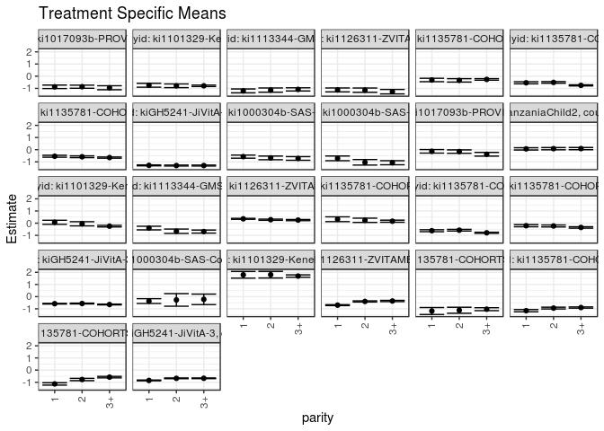

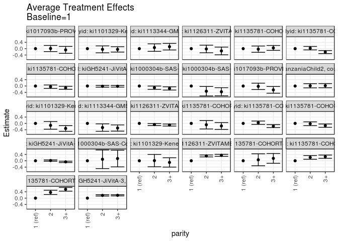

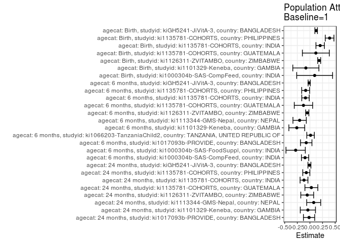

## Results Table

### Parameter: TSM

| agecat | studyid | country | intervention_level | baseline_level | estimate | ci_lower | ci_upper |
| --- | --- | --- | --- | --- | --- | --- | --- |
| Birth | ki1000304b-SAS-CompFeed | INDIA | 1 | NA | -0.3634146 | -0.5587651 | -0.1680641 |
| Birth | ki1000304b-SAS-CompFeed | INDIA | 2 | NA | -0.2690909 | -0.7870046 | 0.2488228 |
| Birth | ki1000304b-SAS-CompFeed | INDIA | 3+ | NA | -0.2227160 | -0.6551313 | 0.2096992 |
| Birth | ki1101329-Keneba | GAMBIA | 1 | NA | 1.7942958 | 1.5187784 | 2.0698132 |
| Birth | ki1101329-Keneba | GAMBIA | 2 | NA | 1.8048872 | 1.5315044 | 2.0782701 |
| Birth | ki1101329-Keneba | GAMBIA | 3+ | NA | 1.6907178 | 1.5926613 | 1.7887743 |
| Birth | ki1126311-ZVITAMBO | ZIMBABWE | 1 | NA | -0.6987448 | -0.7379920 | -0.6594976 |
| Birth | ki1126311-ZVITAMBO | ZIMBABWE | 2 | NA | -0.3937635 | -0.4405965 | -0.3469305 |
| Birth | ki1126311-ZVITAMBO | ZIMBABWE | 3+ | NA | -0.3573243 | -0.4068038 | -0.3078448 |
| Birth | ki1135781-COHORTS | GUATEMALA | 1 | NA | -1.1797872 | -1.4650692 | -0.8945053 |
| Birth | ki1135781-COHORTS | GUATEMALA | 2 | NA | -1.1183898 | -1.3645589 | -0.8722208 |
| Birth | ki1135781-COHORTS | GUATEMALA | 3+ | NA | -1.0296140 | -1.1495677 | -0.9096603 |
| Birth | ki1135781-COHORTS | INDIA | 1 | NA | -1.1529953 | -1.2447465 | -1.0612441 |
| Birth | ki1135781-COHORTS | INDIA | 2 | NA | -0.9408961 | -1.0142407 | -0.8675516 |
| Birth | ki1135781-COHORTS | INDIA | 3+ | NA | -0.8953763 | -0.9449512 | -0.8458015 |
| Birth | ki1135781-COHORTS | PHILIPPINES | 1 | NA | -1.1326875 | -1.2287573 | -1.0366177 |
| Birth | ki1135781-COHORTS | PHILIPPINES | 2 | NA | -0.7699696 | -0.8650746 | -0.6748645 |
| Birth | ki1135781-COHORTS | PHILIPPINES | 3+ | NA | -0.5757615 | -0.6376536 | -0.5138695 |
| Birth | kiGH5241-JiVitA-3 | BANGLADESH | 1 | NA | -0.8477824 | -0.8786530 | -0.8169117 |
| Birth | kiGH5241-JiVitA-3 | BANGLADESH | 2 | NA | -0.6749431 | -0.7066224 | -0.6432638 |
| Birth | kiGH5241-JiVitA-3 | BANGLADESH | 3+ | NA | -0.6699513 | -0.6996649 | -0.6402378 |
| 6 months | ki1000304b-SAS-CompFeed | INDIA | 1 | NA | -0.5695281 | -0.6974230 | -0.4416331 |
| 6 months | ki1000304b-SAS-CompFeed | INDIA | 2 | NA | -0.6747020 | -0.8267292 | -0.5226748 |
| 6 months | ki1000304b-SAS-CompFeed | INDIA | 3+ | NA | -0.7203750 | -0.8706403 | -0.5701097 |
| 6 months | ki1000304b-SAS-FoodSuppl | INDIA | 1 | NA | -0.7120833 | -0.9054612 | -0.5187055 |
| 6 months | ki1000304b-SAS-FoodSuppl | INDIA | 2 | NA | -1.0380952 | -1.2649180 | -0.8112725 |
| 6 months | ki1000304b-SAS-FoodSuppl | INDIA | 3+ | NA | -1.0715668 | -1.2385167 | -0.9046169 |
| 6 months | ki1017093b-PROVIDE | BANGLADESH | 1 | NA | -0.1351264 | -0.2793218 | 0.0090690 |
| 6 months | ki1017093b-PROVIDE | BANGLADESH | 2 | NA | -0.1557311 | -0.2953713 | -0.0160910 |
| 6 months | ki1017093b-PROVIDE | BANGLADESH | 3+ | NA | -0.3757547 | -0.5283479 | -0.2231616 |
| 6 months | ki1066203-TanzaniaChild2 | TANZANIA, UNITED REPUBLIC OF | 1 | NA | 0.0667796 | -0.0263353 | 0.1598944 |
| 6 months | ki1066203-TanzaniaChild2 | TANZANIA, UNITED REPUBLIC OF | 2 | NA | 0.0835908 | -0.0083426 | 0.1755242 |
| 6 months | ki1066203-TanzaniaChild2 | TANZANIA, UNITED REPUBLIC OF | 3+ | NA | 0.0892021 | -0.0012958 | 0.1797001 |
| 6 months | ki1101329-Keneba | GAMBIA | 1 | NA | 0.0724561 | -0.0951335 | 0.2400457 |
| 6 months | ki1101329-Keneba | GAMBIA | 2 | NA | -0.0518201 | -0.2242735 | 0.1206332 |
| 6 months | ki1101329-Keneba | GAMBIA | 3+ | NA | -0.2450948 | -0.3112798 | -0.1789099 |
| 6 months | ki1113344-GMS-Nepal | NEPAL | 1 | NA | -0.4010131 | -0.5499698 | -0.2520563 |
| 6 months | ki1113344-GMS-Nepal | NEPAL | 2 | NA | -0.6633557 | -0.8441980 | -0.4825134 |
| 6 months | ki1113344-GMS-Nepal | NEPAL | 3+ | NA | -0.6908301 | -0.8163965 | -0.5652638 |
| 6 months | ki1126311-ZVITAMBO | ZIMBABWE | 1 | NA | 0.3576256 | 0.3175650 | 0.3976861 |
| 6 months | ki1126311-ZVITAMBO | ZIMBABWE | 2 | NA | 0.2849364 | 0.2366402 | 0.3332325 |
| 6 months | ki1126311-ZVITAMBO | ZIMBABWE | 3+ | NA | 0.2546652 | 0.2061495 | 0.3031809 |
| 6 months | ki1135781-COHORTS | GUATEMALA | 1 | NA | 0.3220455 | 0.1254142 | 0.5186767 |
| 6 months | ki1135781-COHORTS | GUATEMALA | 2 | NA | 0.2369065 | 0.0615093 | 0.4123036 |
| 6 months | ki1135781-COHORTS | GUATEMALA | 3+ | NA | 0.1610694 | 0.0761466 | 0.2459922 |
| 6 months | ki1135781-COHORTS | INDIA | 1 | NA | -0.6192443 | -0.6996552 | -0.5388334 |
| 6 months | ki1135781-COHORTS | INDIA | 2 | NA | -0.5773193 | -0.6450617 | -0.5095769 |
| 6 months | ki1135781-COHORTS | INDIA | 3+ | NA | -0.7911179 | -0.8379869 | -0.7442489 |
| 6 months | ki1135781-COHORTS | PHILIPPINES | 1 | NA | -0.2095296 | -0.2972306 | -0.1218286 |
| 6 months | ki1135781-COHORTS | PHILIPPINES | 2 | NA | -0.2310049 | -0.3121896 | -0.1498203 |
| 6 months | ki1135781-COHORTS | PHILIPPINES | 3+ | NA | -0.3505902 | -0.4074607 | -0.2937196 |
| 6 months | kiGH5241-JiVitA-3 | BANGLADESH | 1 | NA | -0.5787723 | -0.6080163 | -0.5495283 |
| 6 months | kiGH5241-JiVitA-3 | BANGLADESH | 2 | NA | -0.5649481 | -0.5963838 | -0.5335124 |
| 6 months | kiGH5241-JiVitA-3 | BANGLADESH | 3+ | NA | -0.6471559 | -0.6794990 | -0.6148128 |
| 24 months | ki1017093b-PROVIDE | BANGLADESH | 1 | NA | -0.8707583 | -1.0145091 | -0.7270075 |
| 24 months | ki1017093b-PROVIDE | BANGLADESH | 2 | NA | -0.8614554 | -0.9894016 | -0.7335092 |
| 24 months | ki1017093b-PROVIDE | BANGLADESH | 3+ | NA | -0.9481169 | -1.1113339 | -0.7848998 |
| 24 months | ki1101329-Keneba | GAMBIA | 1 | NA | -0.7427859 | -0.9002662 | -0.5853056 |
| 24 months | ki1101329-Keneba | GAMBIA | 2 | NA | -0.7875995 | -0.9380261 | -0.6371730 |
| 24 months | ki1101329-Keneba | GAMBIA | 3+ | NA | -0.7879374 | -0.8474705 | -0.7284044 |
| 24 months | ki1113344-GMS-Nepal | NEPAL | 1 | NA | -1.2067279 | -1.3662688 | -1.0471871 |
| 24 months | ki1113344-GMS-Nepal | NEPAL | 2 | NA | -1.1393462 | -1.3120622 | -0.9666301 |
| 24 months | ki1113344-GMS-Nepal | NEPAL | 3+ | NA | -1.0831897 | -1.2142665 | -0.9521128 |
| 24 months | ki1126311-ZVITAMBO | ZIMBABWE | 1 | NA | -1.1268750 | -1.2875322 | -0.9662178 |
| 24 months | ki1126311-ZVITAMBO | ZIMBABWE | 2 | NA | -1.1461983 | -1.3228585 | -0.9695382 |
| 24 months | ki1126311-ZVITAMBO | ZIMBABWE | 3+ | NA | -1.2699291 | -1.4524856 | -1.0873726 |
| 24 months | ki1135781-COHORTS | GUATEMALA | 1 | NA | -0.3101796 | -0.4498621 | -0.1704972 |
| 24 months | ki1135781-COHORTS | GUATEMALA | 2 | NA | -0.3416556 | -0.4820595 | -0.2012518 |
| 24 months | ki1135781-COHORTS | GUATEMALA | 3+ | NA | -0.2630211 | -0.3275210 | -0.1985212 |
| 24 months | ki1135781-COHORTS | INDIA | 1 | NA | -0.5394474 | -0.6242759 | -0.4546189 |
| 24 months | ki1135781-COHORTS | INDIA | 2 | NA | -0.5091398 | -0.5771205 | -0.4411590 |
| 24 months | ki1135781-COHORTS | INDIA | 3+ | NA | -0.7530828 | -0.7990574 | -0.7071083 |
| 24 months | ki1135781-COHORTS | PHILIPPINES | 1 | NA | -0.5384895 | -0.6177702 | -0.4592088 |
| 24 months | ki1135781-COHORTS | PHILIPPINES | 2 | NA | -0.5811765 | -0.6541762 | -0.5081768 |
| 24 months | ki1135781-COHORTS | PHILIPPINES | 3+ | NA | -0.6483357 | -0.6984875 | -0.5981840 |
| 24 months | kiGH5241-JiVitA-3 | BANGLADESH | 1 | NA | -1.2872229 | -1.3260240 | -1.2484218 |
| 24 months | kiGH5241-JiVitA-3 | BANGLADESH | 2 | NA | -1.3029942 | -1.3429191 | -1.2630692 |
| 24 months | kiGH5241-JiVitA-3 | BANGLADESH | 3+ | NA | -1.3029193 | -1.3421368 | -1.2637018 |

### Parameter: E(Y)

| agecat | studyid | country | intervention_level | baseline_level | estimate | ci_lower | ci_upper |
| --- | --- | --- | --- | --- | --- | --- | --- |
| Birth | ki1000304b-SAS-CompFeed | INDIA | NA | NA | -0.2697590 | -0.5399211 | 0.0004030 |
| Birth | ki1101329-Keneba | GAMBIA | NA | NA | 1.7138545 | 1.6262621 | 1.8014469 |
| Birth | ki1126311-ZVITAMBO | ZIMBABWE | NA | NA | -0.5152877 | -0.5411394 | -0.4894359 |
| Birth | ki1135781-COHORTS | GUATEMALA | NA | NA | -1.0621429 | -1.1631387 | -0.9611471 |
| Birth | ki1135781-COHORTS | INDIA | NA | NA | -0.9498080 | -0.9874148 | -0.9122013 |
| Birth | ki1135781-COHORTS | PHILIPPINES | NA | NA | -0.7427251 | -0.7890855 | -0.6963647 |
| Birth | kiGH5241-JiVitA-3 | BANGLADESH | NA | NA | -0.7238886 | -0.7437224 | -0.7040548 |
| 6 months | ki1000304b-SAS-CompFeed | INDIA | NA | NA | -0.6657084 | -0.8024377 | -0.5289791 |
| 6 months | ki1000304b-SAS-FoodSuppl | INDIA | NA | NA | -0.9946381 | -1.1114079 | -0.8778682 |
| 6 months | ki1017093b-PROVIDE | BANGLADESH | NA | NA | -0.2083706 | -0.2927992 | -0.1239419 |
| 6 months | ki1066203-TanzaniaChild2 | TANZANIA, UNITED REPUBLIC OF | NA | NA | 0.0797179 | 0.0266621 | 0.1327737 |
| 6 months | ki1101329-Keneba | GAMBIA | NA | NA | -0.1874118 | -0.2456850 | -0.1291387 |
| 6 months | ki1113344-GMS-Nepal | NEPAL | NA | NA | -0.6047987 | -0.6909649 | -0.5186325 |
| 6 months | ki1126311-ZVITAMBO | ZIMBABWE | NA | NA | 0.3048076 | 0.2787350 | 0.3308802 |
| 6 months | ki1135781-COHORTS | GUATEMALA | NA | NA | 0.1940810 | 0.1226351 | 0.2655269 |
| 6 months | ki1135781-COHORTS | INDIA | NA | NA | -0.7068611 | -0.7417800 | -0.6719423 |
| 6 months | ki1135781-COHORTS | PHILIPPINES | NA | NA | -0.2938433 | -0.3352064 | -0.2524802 |
| 6 months | kiGH5241-JiVitA-3 | BANGLADESH | NA | NA | -0.5932502 | -0.6127743 | -0.5737261 |
| 24 months | ki1017093b-PROVIDE | BANGLADESH | NA | NA | -0.8879412 | -0.9708680 | -0.8050144 |
| 24 months | ki1101329-Keneba | GAMBIA | NA | NA | -0.7834078 | -0.8357743 | -0.7310414 |
| 24 months | ki1113344-GMS-Nepal | NEPAL | NA | NA | -1.1315863 | -1.2192240 | -1.0439487 |
| 24 months | ki1126311-ZVITAMBO | ZIMBABWE | NA | NA | -1.1802133 | -1.2803837 | -1.0800428 |
| 24 months | ki1135781-COHORTS | GUATEMALA | NA | NA | -0.2813755 | -0.3354674 | -0.2272835 |
| 24 months | ki1135781-COHORTS | INDIA | NA | NA | -0.6564729 | -0.6914450 | -0.6215007 |
| 24 months | ki1135781-COHORTS | PHILIPPINES | NA | NA | -0.6099592 | -0.6467541 | -0.5731643 |
| 24 months | kiGH5241-JiVitA-3 | BANGLADESH | NA | NA | -1.2971774 | -1.3204904 | -1.2738644 |

### Parameter: ATE

| agecat | studyid | country | intervention_level | baseline_level | estimate | ci_lower | ci_upper |
| --- | --- | --- | --- | --- | --- | --- | --- |
| Birth | ki1000304b-SAS-CompFeed | INDIA | 1 | 1 | 0.0000000 | 0.0000000 | 0.0000000 |
| Birth | ki1000304b-SAS-CompFeed | INDIA | 2 | 1 | 0.0943237 | -0.4914787 | 0.6801262 |
| Birth | ki1000304b-SAS-CompFeed | INDIA | 3+ | 1 | 0.1406986 | -0.3836638 | 0.6650610 |
| Birth | ki1101329-Keneba | GAMBIA | 1 | 1 | 0.0000000 | 0.0000000 | 0.0000000 |
| Birth | ki1101329-Keneba | GAMBIA | 2 | 1 | 0.0105914 | -0.3775426 | 0.3987255 |
| Birth | ki1101329-Keneba | GAMBIA | 3+ | 1 | -0.1035780 | -0.3960244 | 0.1888684 |
| Birth | ki1126311-ZVITAMBO | ZIMBABWE | 1 | 1 | 0.0000000 | 0.0000000 | 0.0000000 |
| Birth | ki1126311-ZVITAMBO | ZIMBABWE | 2 | 1 | 0.3049813 | 0.2438775 | 0.3660851 |
| Birth | ki1126311-ZVITAMBO | ZIMBABWE | 3+ | 1 | 0.3414205 | 0.2782655 | 0.4045756 |
| Birth | ki1135781-COHORTS | GUATEMALA | 1 | 1 | 0.0000000 | 0.0000000 | 0.0000000 |
| Birth | ki1135781-COHORTS | GUATEMALA | 2 | 1 | 0.0613974 | -0.3154116 | 0.4382064 |
| Birth | ki1135781-COHORTS | GUATEMALA | 3+ | 1 | 0.1501733 | -0.1593016 | 0.4596481 |
| Birth | ki1135781-COHORTS | INDIA | 1 | 1 | 0.0000000 | 0.0000000 | 0.0000000 |
| Birth | ki1135781-COHORTS | INDIA | 2 | 1 | 0.2120992 | 0.0946355 | 0.3295628 |
| Birth | ki1135781-COHORTS | INDIA | 3+ | 1 | 0.2576190 | 0.1533312 | 0.3619068 |
| Birth | ki1135781-COHORTS | PHILIPPINES | 1 | 1 | 0.0000000 | 0.0000000 | 0.0000000 |
| Birth | ki1135781-COHORTS | PHILIPPINES | 2 | 1 | 0.3627179 | 0.2275351 | 0.4979007 |
| Birth | ki1135781-COHORTS | PHILIPPINES | 3+ | 1 | 0.5569260 | 0.4426454 | 0.6712065 |
| Birth | kiGH5241-JiVitA-3 | BANGLADESH | 1 | 1 | 0.0000000 | 0.0000000 | 0.0000000 |
| Birth | kiGH5241-JiVitA-3 | BANGLADESH | 2 | 1 | 0.1728392 | 0.1299653 | 0.2157131 |
| Birth | kiGH5241-JiVitA-3 | BANGLADESH | 3+ | 1 | 0.1778310 | 0.1385490 | 0.2171130 |
| 6 months | ki1000304b-SAS-CompFeed | INDIA | 1 | 1 | 0.0000000 | 0.0000000 | 0.0000000 |
| 6 months | ki1000304b-SAS-CompFeed | INDIA | 2 | 1 | -0.1051739 | -0.2086042 | -0.0017436 |
| 6 months | ki1000304b-SAS-CompFeed | INDIA | 3+ | 1 | -0.1508469 | -0.2528162 | -0.0488777 |
| 6 months | ki1000304b-SAS-FoodSuppl | INDIA | 1 | 1 | 0.0000000 | 0.0000000 | 0.0000000 |
| 6 months | ki1000304b-SAS-FoodSuppl | INDIA | 2 | 1 | -0.3260119 | -0.6240783 | -0.0279455 |
| 6 months | ki1000304b-SAS-FoodSuppl | INDIA | 3+ | 1 | -0.3594835 | -0.6149581 | -0.1040089 |
| 6 months | ki1017093b-PROVIDE | BANGLADESH | 1 | 1 | 0.0000000 | 0.0000000 | 0.0000000 |
| 6 months | ki1017093b-PROVIDE | BANGLADESH | 2 | 1 | -0.0206047 | -0.2213326 | 0.1801231 |
| 6 months | ki1017093b-PROVIDE | BANGLADESH | 3+ | 1 | -0.2406283 | -0.4505735 | -0.0306832 |
| 6 months | ki1066203-TanzaniaChild2 | TANZANIA, UNITED REPUBLIC OF | 1 | 1 | 0.0000000 | 0.0000000 | 0.0000000 |
| 6 months | ki1066203-TanzaniaChild2 | TANZANIA, UNITED REPUBLIC OF | 2 | 1 | 0.0168112 | -0.1140403 | 0.1476628 |
| 6 months | ki1066203-TanzaniaChild2 | TANZANIA, UNITED REPUBLIC OF | 3+ | 1 | 0.0224225 | -0.1074245 | 0.1522696 |
| 6 months | ki1101329-Keneba | GAMBIA | 1 | 1 | 0.0000000 | 0.0000000 | 0.0000000 |
| 6 months | ki1101329-Keneba | GAMBIA | 2 | 1 | -0.1242762 | -0.3647475 | 0.1161950 |
| 6 months | ki1101329-Keneba | GAMBIA | 3+ | 1 | -0.3175509 | -0.4977362 | -0.1373657 |
| 6 months | ki1113344-GMS-Nepal | NEPAL | 1 | 1 | 0.0000000 | 0.0000000 | 0.0000000 |
| 6 months | ki1113344-GMS-Nepal | NEPAL | 2 | 1 | -0.2623426 | -0.4966332 | -0.0280521 |
| 6 months | ki1113344-GMS-Nepal | NEPAL | 3+ | 1 | -0.2898171 | -0.4846375 | -0.0949966 |
| 6 months | ki1126311-ZVITAMBO | ZIMBABWE | 1 | 1 | 0.0000000 | 0.0000000 | 0.0000000 |
| 6 months | ki1126311-ZVITAMBO | ZIMBABWE | 2 | 1 | -0.0726892 | -0.1354377 | -0.0099408 |
| 6 months | ki1126311-ZVITAMBO | ZIMBABWE | 3+ | 1 | -0.1029604 | -0.1658779 | -0.0400428 |
| 6 months | ki1135781-COHORTS | GUATEMALA | 1 | 1 | 0.0000000 | 0.0000000 | 0.0000000 |
| 6 months | ki1135781-COHORTS | GUATEMALA | 2 | 1 | -0.0851390 | -0.3486310 | 0.1783530 |
| 6 months | ki1135781-COHORTS | GUATEMALA | 3+ | 1 | -0.1609761 | -0.3751623 | 0.0532101 |
| 6 months | ki1135781-COHORTS | INDIA | 1 | 1 | 0.0000000 | 0.0000000 | 0.0000000 |
| 6 months | ki1135781-COHORTS | INDIA | 2 | 1 | 0.0419250 | -0.0632175 | 0.1470674 |
| 6 months | ki1135781-COHORTS | INDIA | 3+ | 1 | -0.1718736 | -0.2649468 | -0.0788005 |
| 6 months | ki1135781-COHORTS | PHILIPPINES | 1 | 1 | 0.0000000 | 0.0000000 | 0.0000000 |
| 6 months | ki1135781-COHORTS | PHILIPPINES | 2 | 1 | -0.0214753 | -0.1409844 | 0.0980337 |
| 6 months | ki1135781-COHORTS | PHILIPPINES | 3+ | 1 | -0.1410605 | -0.2455867 | -0.0365344 |
| 6 months | kiGH5241-JiVitA-3 | BANGLADESH | 1 | 1 | 0.0000000 | 0.0000000 | 0.0000000 |
| 6 months | kiGH5241-JiVitA-3 | BANGLADESH | 2 | 1 | 0.0138242 | -0.0271090 | 0.0547574 |
| 6 months | kiGH5241-JiVitA-3 | BANGLADESH | 3+ | 1 | -0.0683836 | -0.1090007 | -0.0277666 |
| 24 months | ki1017093b-PROVIDE | BANGLADESH | 1 | 1 | 0.0000000 | 0.0000000 | 0.0000000 |
| 24 months | ki1017093b-PROVIDE | BANGLADESH | 2 | 1 | 0.0093029 | -0.1831406 | 0.2017464 |
| 24 months | ki1017093b-PROVIDE | BANGLADESH | 3+ | 1 | -0.0773586 | -0.2948536 | 0.1401365 |
| 24 months | ki1101329-Keneba | GAMBIA | 1 | 1 | 0.0000000 | 0.0000000 | 0.0000000 |
| 24 months | ki1101329-Keneba | GAMBIA | 2 | 1 | -0.0448136 | -0.2625938 | 0.1729665 |
| 24 months | ki1101329-Keneba | GAMBIA | 3+ | 1 | -0.0451515 | -0.2135090 | 0.1232059 |
| 24 months | ki1113344-GMS-Nepal | NEPAL | 1 | 1 | 0.0000000 | 0.0000000 | 0.0000000 |
| 24 months | ki1113344-GMS-Nepal | NEPAL | 2 | 1 | 0.0673818 | -0.1677440 | 0.3025076 |
| 24 months | ki1113344-GMS-Nepal | NEPAL | 3+ | 1 | 0.1235383 | -0.0829428 | 0.3300193 |
| 24 months | ki1126311-ZVITAMBO | ZIMBABWE | 1 | 1 | 0.0000000 | 0.0000000 | 0.0000000 |
| 24 months | ki1126311-ZVITAMBO | ZIMBABWE | 2 | 1 | -0.0193233 | -0.2581110 | 0.2194643 |
| 24 months | ki1126311-ZVITAMBO | ZIMBABWE | 3+ | 1 | -0.1430541 | -0.3862364 | 0.1001282 |
| 24 months | ki1135781-COHORTS | GUATEMALA | 1 | 1 | 0.0000000 | 0.0000000 | 0.0000000 |
| 24 months | ki1135781-COHORTS | GUATEMALA | 2 | 1 | -0.0314760 | -0.2295276 | 0.1665756 |
| 24 months | ki1135781-COHORTS | GUATEMALA | 3+ | 1 | 0.0471585 | -0.1066967 | 0.2010138 |
| 24 months | ki1135781-COHORTS | INDIA | 1 | 1 | 0.0000000 | 0.0000000 | 0.0000000 |
| 24 months | ki1135781-COHORTS | INDIA | 2 | 1 | 0.0303076 | -0.0783996 | 0.1390148 |
| 24 months | ki1135781-COHORTS | INDIA | 3+ | 1 | -0.2136354 | -0.3101213 | -0.1171495 |
| 24 months | ki1135781-COHORTS | PHILIPPINES | 1 | 1 | 0.0000000 | 0.0000000 | 0.0000000 |
| 24 months | ki1135781-COHORTS | PHILIPPINES | 2 | 1 | -0.0426870 | -0.1504570 | 0.0650830 |
| 24 months | ki1135781-COHORTS | PHILIPPINES | 3+ | 1 | -0.1098463 | -0.2036579 | -0.0160346 |
| 24 months | kiGH5241-JiVitA-3 | BANGLADESH | 1 | 1 | 0.0000000 | 0.0000000 | 0.0000000 |
| 24 months | kiGH5241-JiVitA-3 | BANGLADESH | 2 | 1 | -0.0157712 | -0.0715526 | 0.0400101 |
| 24 months | kiGH5241-JiVitA-3 | BANGLADESH | 3+ | 1 | -0.0156964 | -0.0685428 | 0.0371500 |

### Parameter: PAR

| agecat | studyid | country | intervention_level | baseline_level | estimate | ci_lower | ci_upper |
| --- | --- | --- | --- | --- | --- | --- | --- |
| Birth | ki1000304b-SAS-CompFeed | INDIA | 1 | NA | 0.0936556 | -0.2620788 | 0.4493900 |
| Birth | ki1101329-Keneba | GAMBIA | 1 | NA | -0.0804413 | -0.3390843 | 0.1782017 |
| Birth | ki1126311-ZVITAMBO | ZIMBABWE | 1 | NA | 0.1834572 | 0.1537560 | 0.2131584 |
| Birth | ki1135781-COHORTS | GUATEMALA | 1 | NA | 0.1176444 | -0.1494645 | 0.3847533 |
| Birth | ki1135781-COHORTS | INDIA | 1 | NA | 0.2031873 | 0.1193242 | 0.2870503 |
| Birth | ki1135781-COHORTS | PHILIPPINES | 1 | NA | 0.3899624 | 0.3045012 | 0.4754237 |
| Birth | kiGH5241-JiVitA-3 | BANGLADESH | 1 | NA | 0.1238938 | 0.0985523 | 0.1492352 |
| 6 months | ki1000304b-SAS-CompFeed | INDIA | 1 | NA | -0.0961803 | -0.1675004 | -0.0248602 |
| 6 months | ki1000304b-SAS-FoodSuppl | INDIA | 1 | NA | -0.2825547 | -0.4738491 | -0.0912604 |
| 6 months | ki1017093b-PROVIDE | BANGLADESH | 1 | NA | -0.0732442 | -0.1865769 | 0.0400885 |
| 6 months | ki1066203-TanzaniaChild2 | TANZANIA, UNITED REPUBLIC OF | 1 | NA | 0.0129383 | -0.0617637 | 0.0876404 |
| 6 months | ki1101329-Keneba | GAMBIA | 1 | NA | -0.2598680 | -0.4171353 | -0.1026006 |
| 6 months | ki1113344-GMS-Nepal | NEPAL | 1 | NA | -0.2037856 | -0.3362738 | -0.0712975 |
| 6 months | ki1126311-ZVITAMBO | ZIMBABWE | 1 | NA | -0.0528180 | -0.0845764 | -0.0210596 |
| 6 months | ki1135781-COHORTS | GUATEMALA | 1 | NA | -0.1279645 | -0.3100879 | 0.0541590 |
| 6 months | ki1135781-COHORTS | INDIA | 1 | NA | -0.0876169 | -0.1614339 | -0.0137999 |
| 6 months | ki1135781-COHORTS | PHILIPPINES | 1 | NA | -0.0843137 | -0.1626675 | -0.0059598 |
| 6 months | kiGH5241-JiVitA-3 | BANGLADESH | 1 | NA | -0.0144779 | -0.0357954 | 0.0068396 |
| 24 months | ki1017093b-PROVIDE | BANGLADESH | 1 | NA | -0.0171829 | -0.1287807 | 0.0944149 |
| 24 months | ki1101329-Keneba | GAMBIA | 1 | NA | -0.0406219 | -0.1909679 | 0.1097240 |
| 24 months | ki1113344-GMS-Nepal | NEPAL | 1 | NA | 0.0751416 | -0.0635359 | 0.2138191 |
| 24 months | ki1126311-ZVITAMBO | ZIMBABWE | 1 | NA | -0.0533383 | -0.1809029 | 0.0742264 |
| 24 months | ki1135781-COHORTS | GUATEMALA | 1 | NA | 0.0288042 | -0.0991829 | 0.1567912 |
| 24 months | ki1135781-COHORTS | INDIA | 1 | NA | -0.1170255 | -0.1945607 | -0.0394902 |
| 24 months | ki1135781-COHORTS | PHILIPPINES | 1 | NA | -0.0714697 | -0.1418593 | -0.0010800 |
| 24 months | kiGH5241-JiVitA-3 | BANGLADESH | 1 | NA | -0.0099545 | -0.0394757 | 0.0195667 |